# Ahmet Yetkin Eser - BDA 505 Final

### 2)

- I used to partnerAreas json file from class.

```r
library(RJSONIO)
library("jsonlite")
setwd("/Users/yetkineser/Desktop/mef Big Data/final/comtrade_tables")
partnerAreas <- fromJSON("partnerAreas.json")

partnerAreas$more %>% kable()
```

| FALSE |
| --- |

```r
head(partnerAreas$results,6) %>%
  kable()
```

| id | text |
| --- | --- |
| all | All |
| 0 | World |
| 4 | Afghanistan |
| 472 | Africa CAMEU region, nes |
| 8 | Albania |
| 12 | Algeria |

```r
tail(partnerAreas$results,6) %>%
  kable()
```

|  | id | text |
| --- | --- | --- |
| 288 | 876 | Wallis and Futuna Isds |
| 289 | 879 | Western Asia, nes |
| 290 | 732 | Western Sahara |
| 291 | 887 | Yemen |
| 292 | 894 | Zambia |
| 293 | 716 | Zimbabwe |

```r
partnerAreas$results%>%
  filter(text=='Turkey') %>%
  kable()
```

| id | text |
| --- | --- |
| 792 | Turkey |

### 3)

- **I run this code for open sandbox and use mapper and reducer function.**
- start_sandbox-hdp.sh
- scp -P 2223 deneme root@localhost:/data
- ssh root@localhost -p 2223
- su hdfs
- cd /
- hdfs dfs -ls /user/data
- hdfs dfs -ls /user/data/imdb
- cat /data/imdb/* | wc -l
- This is the output:

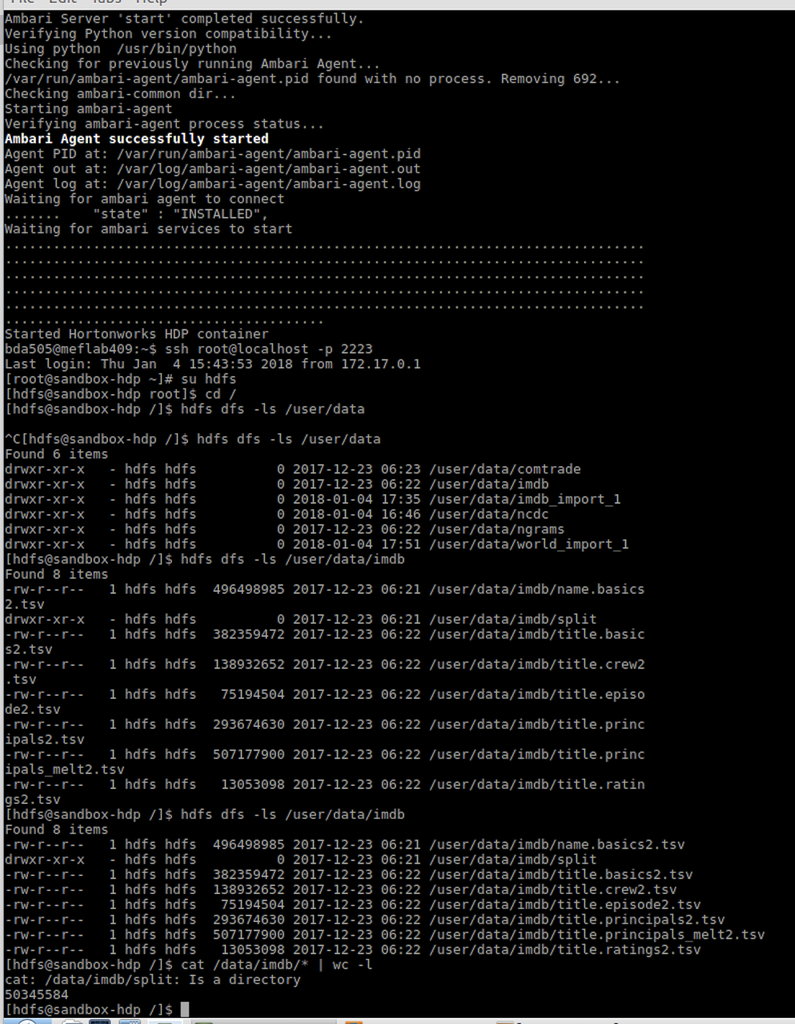

```r
library(knitr)
include_graphics("/Users/yetkineser/Desktop/mef Big Data/final/mapreduce1.png")
```

- **First I use mapper function. I added yout code from class where statement and I take number of movies between 2013 and 2017**
- for file in /data/imdb/split/*; do cut -f 6 $file | q “select c1,count(c1) from - where c1 between 2013 and 2017 group by c1”;done

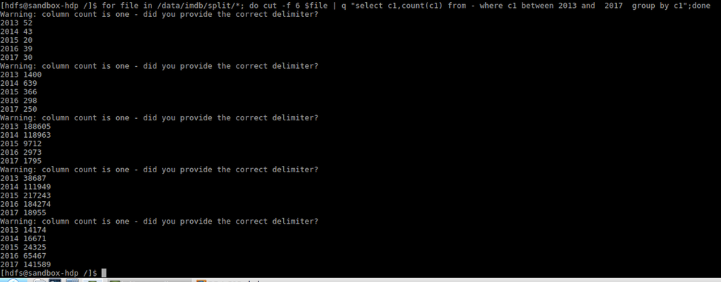

```r
library(knitr)
include_graphics("/Users/yetkineser/Desktop/mef Big Data/final/mapreduce2.png")
```

- **Second I use mapper and reducer function together**
- for file in /data/imdb/split/*; do cut -f 6 $file | q “select c1,count(c1) from - where c1 between 2013 and 2017 group by c1”;done |q “select c1,sum(c2) from - group by c1”

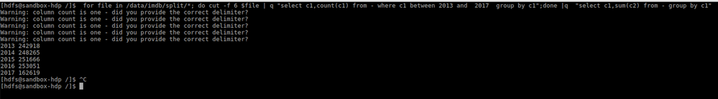

```r
library(knitr)
include_graphics("/Users/yetkineser/Desktop/mef Big Data/final/mapreduce3.png")
```